# STATS 60 Rlab Session 4

Yuchen Wu

2020/7/15

# Recap of session 3

- Transforming data with `dplyr`
  - `select()`: pick variables/**columns** by their names
  - `mutate()`: create new variables/**columns** based on existing ones
  - `arrange()`: reorder **rows**
  - `filter()`: pick **rows** by their values
  - `summarize()`: collapse many **rows** down to a single summary
  - `group_by()`: perform operations at a group level

# Recap of session 3

**ALL of these functions take:**

1. A dataset, and
2. Instructions on what to do with the dataset.

# Recap of session 3

**ALL of these functions take:**

1. A dataset, and
2. Instructions on what to do with the dataset.

**The dataset is either:**

1. The first argument within the function’s parentheses, e.g.

```r
select(df, day)
```

# Recap of session 3

**ALL of these functions take:**

1. A dataset, and
2. Instructions on what to do with the dataset.

**The dataset is either:**

1. The first argument within the function’s parentheses, or
2. Passed to the function through a “pipe” `%>%`, e.g.

```r
df %>% select(day)
```

# Recap of session 3

**ALL of these functions return a dataset!**

You can do three things with this returned dataset:

1. Nothing, in which case it prints to screen.
2. Save it by assigning it to a variable.
3. Don’t save it, but pass it on to another function using a “pipe” `%>%`

# `%>%` syntax with `dplyr`

Take the `mtcars` dataset, select just the `wt` and `mpg` columns, *then select rows with mpg < 15*

```r
mtcars %>%
    select(wt, mpg) %>%
    filter(mpg < 15)
```

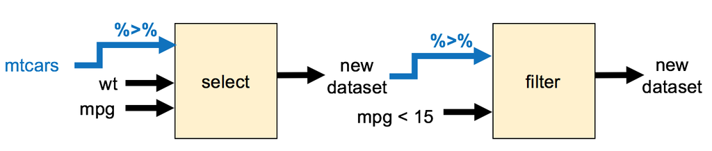

# Agenda for today

# `tidyr::gather()`

E.g. dataset of no. of cases for each country

```r
df
```

```
## # A tibble: 3 x 3
##   country     `1999` `2000`
##   <chr>        <dbl>  <dbl>
## 1 Afghanistan    745   2666
## 2 Brazil       37737  80488
## 3 China       212258 213766
```

# `tidyr::gather()`

**How to make a line plot of no. of cases by year for each country?**

```r
df
```

```
## # A tibble: 3 x 3
##   country     `1999` `2000`
##   <chr>        <dbl>  <dbl>
## 1 Afghanistan    745   2666
## 2 Brazil       37737  80488
## 3 China       212258 213766
```

Probably want something like

```r
ggplot(df) +
    geom_line(aes(x = year, y = cases, group = country))
```

# `tidyr::gather()`

**How to make a line plot of no. of cases by year for each country?**

**Problem:** Column names are values of the variable `year`.

```r
df
```

```
## # A tibble: 3 x 3
##   country     `1999` `2000`
##   <chr>        <dbl>  <dbl>
## 1 Afghanistan    745   2666
## 2 Brazil       37737  80488
## 3 China       212258 213766
```

# `tidyr::gather()`

**How to make a line plot of no. of cases by year for each country?**

**Solution:** Reshape dataset:

```
## # A tibble: 6 x 3
##   country     year   cases
##   <chr>       <chr>  <dbl>
## 1 Afghanistan 1999     745
## 2 Brazil      1999   37737
## 3 China       1999  212258
## 4 Afghanistan 2000    2666
## 5 Brazil      2000   80488
## 6 China       2000  213766
```

# `tidyr::gather()`

**How to make a line plot of no. of cases by year for each country?**

**Solution:** Reshape dataset using `tidyr`’s `gather()`

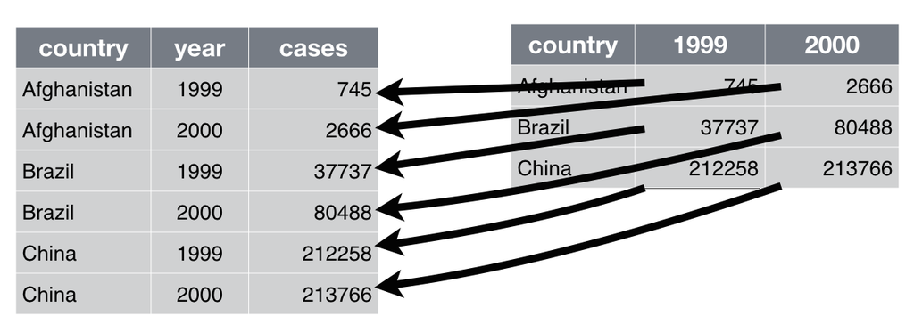

(Source: [R for Data Science](http://r4ds.had.co.nz/tidy-data.html))

# `tidyr::gather()`

**How to make a line plot of no. of cases by year for each country?**

**Solution:** Reshape dataset using `tidyr`’s `gather()`

```r
df %>% gather(`1999`, `2000`, key = "year", value = "cases")
```

```
## # A tibble: 6 x 3
##   country     year   cases
##   <chr>       <chr>  <dbl>
## 1 Afghanistan 1999     745
## 2 Brazil      1999   37737
## 3 China       1999  212258
## 4 Afghanistan 2000    2666
## 5 Brazil      2000   80488
## 6 China       2000  213766
```

# `tidyr::gather()`

**How to make a line plot of no. of cases by year for each country?**

**Solution:** Reshape dataset using `tidyr`’s `gather()`

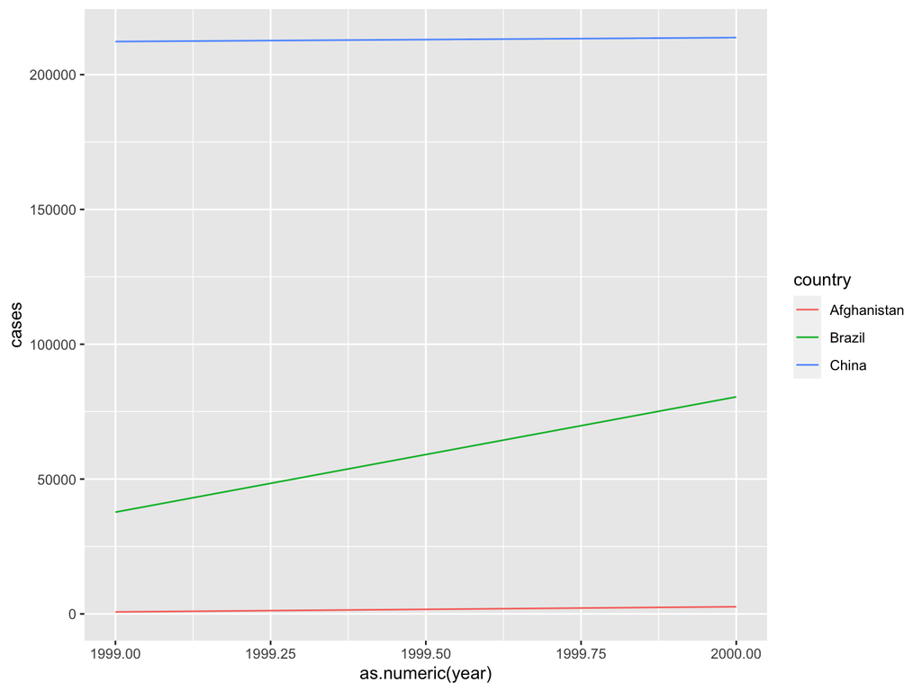

```r
df %>% gather(`1999`, `2000`, key = "year", value = "cases") %>%
    ggplot() +
    geom_line(aes(x = as.numeric(year), y = cases, col = country))
```

# `tidyr::separate()`

E.g. dataset of rate (cases / population) for each country

```r
df
```

```
## # A tibble: 6 x 3
##   country      year rate
##   <chr>       <dbl> <chr>
## 1 Afghanistan  1999 745/19987071
## 2 Afghanistan  2000 2666/20595360
## 3 Brazil       1999 37737/172006362
## 4 Brazil       2000 80488/174504898
## 5 China        1999 212258/1272915272
## 6 China        2000 213766/1280428583
```

# `tidyr::separate()`

**How to get cases and population into columns of their own?**

```r
df
```

```
## # A tibble: 6 x 3
##   country      year rate
##   <chr>       <dbl> <chr>
## 1 Afghanistan  1999 745/19987071
## 2 Afghanistan  2000 2666/20595360
## 3 Brazil       1999 37737/172006362
## 4 Brazil       2000 80488/174504898
## 5 China        1999 212258/1272915272
## 6 China        2000 213766/1280428583
```

# `tidyr::separate()`

**How to get cases and population into columns of their own?**

**Solution:** Use `tidyr`’s `separate()`

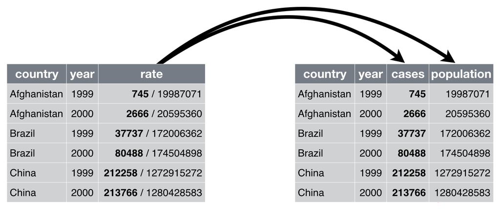

(Source: [R for Data Science](http://r4ds.had.co.nz/tidy-data.html))

# `tidyr::separate()`

**How to get cases and population into columns of their own?**

**Solution:** Use `tidyr`’s `separate()`

```r
df %>% separate(rate, into = c("cases", "population"), sep = "/")
```

```
## # A tibble: 6 x 4
##   country      year cases  population
##   <chr>       <dbl> <chr>  <chr>
## 1 Afghanistan  1999 745    19987071
## 2 Afghanistan  2000 2666   20595360
## 3 Brazil       1999 37737  172006362
## 4 Brazil       2000 80488  174504898
## 5 China        1999 212258 1272915272
## 6 China        2000 213766 1280428583
```

# Where does your data live?

- Data is stored in a **“file”**
  - e.g. `.txt` (text) or `.csv` (comma-separated values) file
- Files belong to a **“folder”/“directory”**
- Folders can be nested within other folders

# Filepath example (Mac)

- Application: Finder
- Default “root” directory: `/`

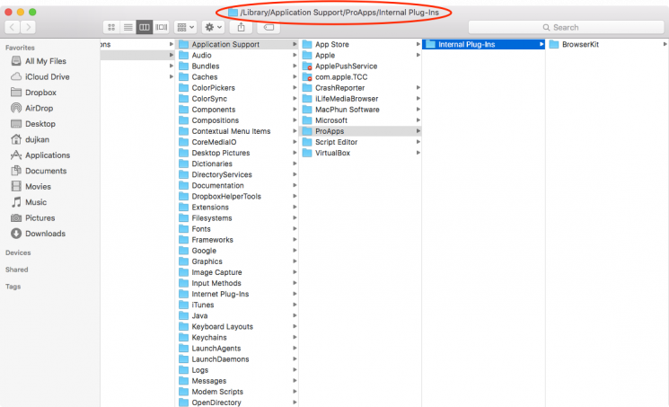

(Source: [iDB](https://www.idownloadblog.com/2015/12/07/how-to-full-file-path-mac-finder-window/))

# Filepath example (Windows)

- Application: File explorer
- Default “root” directory: `C:/`

[figure not shown]

(Source: [Computer Problem and solution](https://amitparashanker.wordpress.com/2016/03/30/how-to-recover-deleted-windows-10-program-files-after-an-update/))

# File paths

- A character string that tells you the location of a file
- **Absolute path:** starts from the “root” directory
  - e.g. `/Users/yuchen/Downloads/datafile.csv`

# File paths

- A character string that tells you the location of a file
- **Absolute path:** starts from the “root” directory
  - e.g. `/Users/yuchen/Downloads/datafile.csv`
- **Relative path:** starts from the current directory (denoted by `.`)
  - e.g. If I am in the folder `/Users/yuchen`: `./Downloads/datafile.csv`
  - e.g. If I am in the folder `/Users/yuchen/Downloads`: `./datafile.csv` or simply `datafile.csv`

# Working directories in R

- Directory where R looks for files that you ask it to load
- Also where R will put any files that you ask it to save
- You can see your current working directory at the top of the console or by typing `getwd()`

# How can I change my working directory in RStudio?

1. You can issue the command `setwd("<path of new directory>")`
2. In the menu bar, click Session > Set Working Directory, then click one of the options in the sub-menu

# Today’s dataset: Drought in California

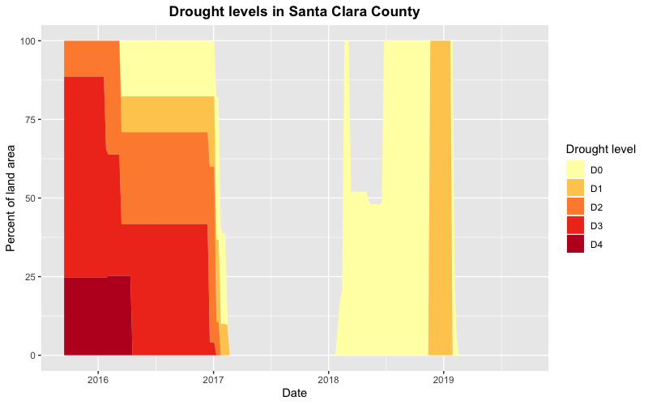

# Data source: United States Drought Monitor (USDM)

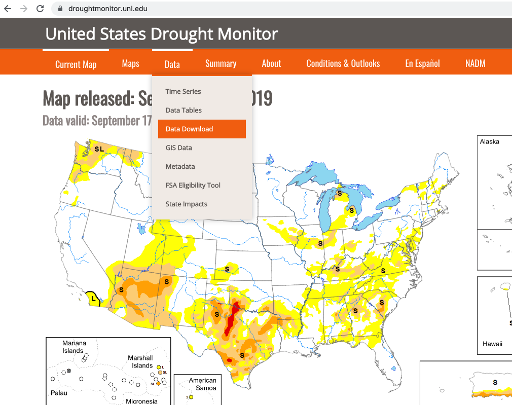

(Source: [droughtmonitor.unl.edu](https://droughtmonitor.unl.edu/))

# USDM: data download

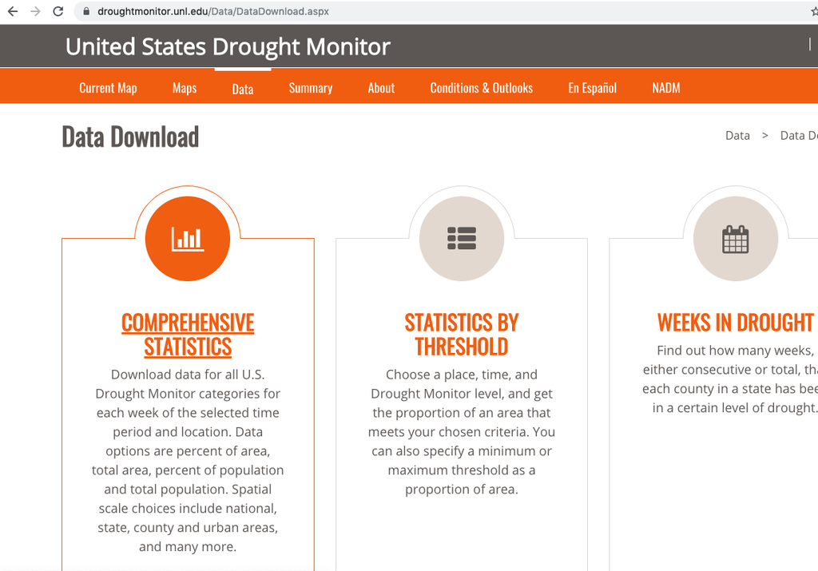

# USDM: data selection

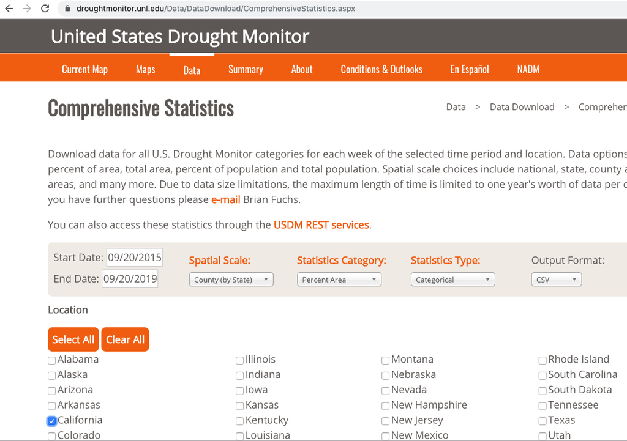

# The data in Excel

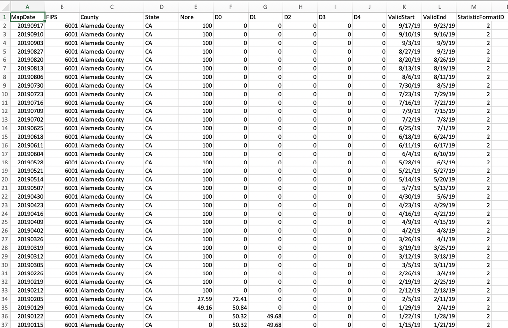

- `None` to `D4`: drought levels of increasing severity
- Numbers: % by land area at that drought severity level